# Value and Consumption Low vs Higher Interest Rates Results Comparison

[Fan Wang](https://fanwangecon.github.io/)

2021-12-06

# 1 Value and Consumption Low vs Higher Interest Rates Results Comparison

This is the example vignette for function: [**snw_vfi_main_bisec_vec**](https://github.com/FanWangEcon/PrjOptiSNW/tree/master/PrjOptiSNW/svalpol/snw_vfi_main_bisec_vec.m) from the [**PrjOptiSNW Package**](https://fanwangecon.github.io/PrjOptiSNW/)**.** This function solves for the V(states) for individuals at lower and higher savings interest rates. Note that welfare improves for all when interest rates go up for savings in a model where borrowing is not allowed. However, a change in the interest rate generates an income effect (higher resources) and changes the relative price of consumption today vs. tomorrow. The change in income increases the incentive to consume, but the change in relative price depresses incentives to consume today. The combined effect of rising interest rate on savings on consumption/savings differs by the state-space; households might overall consume more or less depending on their state-space.

## 1.1 Solve Model at 4 Percent Interest Rate

Solve the benchmark model at 4 percent savings interest rate.

```
% mp_params = snw_mp_param('default_dense');
mp_params = snw_mp_param('default_docdense');
mp_params('beta') = 0.95;
fl_higher_r = 0.04;
fl_lower_r = 0.02;
mp_params('r') = fl_higher_r;
mp_controls = snw_mp_control('default_test');
mp_controls('bl_print_vfi') = false;
mp_controls('bl_print_vfi_verbose') = false;
mp_controls('bl_timer') = true;
[V_ss_r04,~,cons_ss_r04,~] = snw_vfi_main_bisec_vec(mp_params, mp_controls);

Completed SNW_VFI_MAIN_BISEC_VEC;SNW_MP_PARAM=default_docdense;SNW_MP_CONTROL=default_test;time=496.1817
```

## 1.2 Solve Model at 2 Percent Interest Rate

Solve the benchmark model at 2 percent savings interest rate.

```
mp_params('r') = fl_lower_r;
mp_controls = snw_mp_control('default_test');
mp_controls('bl_print_vfi') = false;
mp_controls('bl_print_vfi_verbose') = false;
mp_controls('bl_timer') = true;
[V_ss_r02,~,cons_ss_r02,~] = snw_vfi_main_bisec_vec(mp_params, mp_controls);

Completed SNW_VFI_MAIN_BISEC_VEC;SNW_MP_PARAM=default_docdense;SNW_MP_CONTROL=default_test;time=495.0637
```

## 1.3 Generate Interest Rate Comparison Matrixes

Take the difference between 4 percent and 2 percent savings interest rate results. When interest rates are higher, greater incentive to save, but leads to heterogeneous responses by income and other characteristics, note that this changes both relative prices as well as total resource/budget, so there is both income and price effects that differ in magnitudes depending on the individual’s statespace. Welfare does improve for all higher higher r. Welfare is converted to units in fixed life-time consumption.

```
gamma = mp_params('gamma');
mn_V_gain_r = snw_hh_welfare(V_ss_r04, gamma) - snw_hh_welfare(V_ss_r02, gamma);
mn_C_gain_r = cons_ss_r04 - cons_ss_r02;
fl_r_gap = fl_higher_r - fl_lower_r;
```

## 1.4 Dense Param Results Define Frames

Define the matrix dimensions names and dimension vector values. Policy and Value Functions share the same ND dimensional structure.

```
% Grids:
age_grid = 18:100;
agrid = mp_params('agrid')';
eta_H_grid = mp_params('eta_H_grid')';
eta_S_grid = mp_params('eta_S_grid')';
ar_st_eta_HS_grid = string(cellstr([num2str(eta_H_grid', 'hz=%3.2f;'), num2str(eta_S_grid', 'wz=%3.2f')]));
edu_grid = [0,1];
marry_grid = [0,1];
kids_grid = (1:1:mp_params('n_kidsgrid'))';
% NaN(n_jgrid,n_agrid,n_etagrid,n_educgrid,n_marriedgrid,n_kidsgrid);
cl_mp_datasetdesc = {};
cl_mp_datasetdesc{1} = containers.Map({'name', 'labval'}, {'age', age_grid});
cl_mp_datasetdesc{2} = containers.Map({'name', 'labval'}, {'savings', agrid});
cl_mp_datasetdesc{3} = containers.Map({'name', 'labval'}, {'eta', 1:length(eta_H_grid)});
cl_mp_datasetdesc{4} = containers.Map({'name', 'labval'}, {'edu', edu_grid});
cl_mp_datasetdesc{5} = containers.Map({'name', 'labval'}, {'marry', marry_grid});
cl_mp_datasetdesc{6} = containers.Map({'name', 'labval'}, {'kids', kids_grid});
```

## 1.5 Analyze Difference in V and C with Higher and Lower Savings Interest Rate

The difference between V and C with higher and lower $r$.

```
% Generate some Data
mp_support_graph = containers.Map('KeyType', 'char', 'ValueType', 'any');
mp_support_graph('cl_st_xtitle') = {'Savings States, a'};
mp_support_graph('st_legend_loc') = 'eastoutside';
mp_support_graph('bl_graph_logy') = true; % do not log
mp_support_graph('it_legend_select') = 21; % how many shock legends to show
mp_support_graph('cl_colors') = 'jet';
```

MEAN(MN_V_GAIN(A,Z))

Tabulate value and policies along savings and shocks:

```
% Set
ar_permute = [1,4,5,6,3,2];
% Value Function
st_title = ['MEAN(MN_V_Gain(A,Z)), r_gap=' num2str(fl_r_gap) ];
tb_az_v = ff_summ_nd_array(st_title, mn_V_gain_r, true, ["mean"], 4, 1, cl_mp_datasetdesc, ar_permute);

xxx  MEAN(MN_V_Gain(A,Z)), r_gap=0.02  xxxxxxxxxxxxxxxxxxxxxxxxxxx
    group     savings      mean_eta_1    mean_eta_2    mean_eta_3    mean_eta_4    mean_eta_5    mean_eta_6    mean_eta_7    mean_eta_8    mean_eta_9    mean_eta_10    mean_eta_11    mean_eta_12    mean_eta_13    mean_eta_14    mean_eta_15    mean_eta_16    mean_eta_17    mean_eta_18    mean_eta_19 …
    _____    __________    __________    __________    __________    __________    __________    __________    __________    __________    __________    ___________    ___________    ___________    ___________    ___________    ___________    ___________    ___________    ___________    ___________ …

      1               0    4.6652e-05     4.802e-05    4.9487e-05    5.1045e-05    5.2688e-05    5.4417e-05    5.6233e-05    5.8143e-05    6.0156e-05    6.2282e-05     6.4533e-05     6.6922e-05     6.9466e-05     7.2183e-05     7.5095e-05     7.8226e-05     8.1608e-05     8.5273e-05      8.926e-05  …
      2      0.00051498     4.725e-05    4.8601e-05    5.0052e-05    5.1595e-05    5.3225e-05    5.4941e-05    5.6744e-05    5.8643e-05    6.0644e-05    6.2759e-05        6.5e-05     6.7379e-05     6.9914e-05     7.2622e-05     7.5525e-05     7.8649e-05     8.2023e-05     8.5681e-05     8.9662e-05  …
      3       0.0041199    5.1273e-05    5.2516e-05    5.3868e-05     5.532e-05    5.6863e-05    5.8496e-05    6.0221e-05    6.2043e-05    6.3972e-05    6.6017e-05      6.819e-05     7.0505e-05     7.2979e-05     7.5629e-05     7.8477e-05     8.1549e-05     8.4873e-05     8.8484e-05     9.2422e-05  …
      4        0.013905     6.118e-05    6.2221e-05    6.3373e-05    6.4635e-05    6.5996e-05    6.7452e-05    6.9004e-05    7.0659e-05    7.2424e-05    7.4311e-05      7.633e-05     7.8497e-05     8.0827e-05     8.3339e-05     8.6055e-05     8.9001e-05     9.2206e-05     9.5705e-05     9.9538e-05  …
      5        0.032959    7.7395e-05    7.8196e-05    7.9136e-05    8.0192e-05    8.1347e-05    8.2598e-05    8.3946e-05    8.5399e-05    8.6965e-05    8.8654e-05     9.0479e-05     9.2455e-05     9.4598e-05     9.6926e-05     9.9463e-05     0.00010224     0.00010527     0.00010861      0.0001123  …
      6        0.064373    9.9291e-05    9.9974e-05    0.00010079    0.00010171    0.00010271    0.00010381    0.00010499    0.00010627    0.00010767    0.00010919     0.00011084     0.00011264     0.00011461     0.00011677     0.00011914     0.00012175     0.00012464     0.00012783     0.00013138  …

% Consumption
st_title = ['MEAN(MN_C_Gain(A,Z)), r_gap=' num2str(fl_r_gap) ];
tb_az_c = ff_summ_nd_array(st_title, mn_C_gain_r, true, ["mean"], 4, 1, cl_mp_datasetdesc, ar_permute);

xxx  MEAN(MN_C_Gain(A,Z)), r_gap=0.02  xxxxxxxxxxxxxxxxxxxxxxxxxxx
    group     savings      mean_eta_1     mean_eta_2     mean_eta_3     mean_eta_4     mean_eta_5     mean_eta_6     mean_eta_7     mean_eta_8     mean_eta_9     mean_eta_10    mean_eta_11    mean_eta_12    mean_eta_13    mean_eta_14    mean_eta_15    mean_eta_16    mean_eta_17    mean_eta_18    mea…
    _____    __________    ___________    ___________    ___________    ___________    ___________    ___________    ___________    ___________    ___________    ___________    ___________    ___________    ___________    ___________    ___________    ___________    ___________    ___________    ___…

      1               0              0              0              0              0              0              0              0              0              0              0              0              0              0    -1.7716e-08    -1.1804e-07    -3.4331e-07    -6.7033e-07    -1.1173e-06     -2…
      2      0.00051498     9.0758e-06     9.0577e-06     9.0392e-06     9.0202e-06     9.0007e-06     8.9809e-06     8.9607e-06     8.9401e-06      8.892e-06     8.8281e-06      8.716e-06     8.5347e-06     8.2495e-06     7.8868e-06     7.4602e-06     7.0169e-06     6.6201e-06     6.4778e-06     4.…
      3       0.0041199     6.9258e-05     5.9037e-05     5.5968e-05      5.437e-05     5.3887e-05     5.3137e-05     5.1496e-05     5.0274e-05     4.9607e-05     4.9623e-05     5.0718e-05     5.2199e-05     5.3726e-05     5.5098e-05     5.5565e-05     5.5008e-05     5.4105e-05     5.2427e-05      4…
      4        0.013905      0.0001131     0.00016511     0.00017196     0.00016519     0.00015748      0.0001458     0.00012603     0.00010405     8.0934e-05     5.9412e-05     3.7506e-05     1.5168e-05    -3.3583e-06    -1.2206e-05    -1.3088e-05    -1.5419e-05    -2.2065e-05    -3.8942e-05    -5.…
      5        0.032959     0.00026095     0.00020294      0.0001617     0.00014482     0.00014062     0.00014373     0.00015046     0.00015827     0.00016684     0.00017307     0.00017614     0.00017049     0.00015153     0.00011814     7.6562e-05     3.1132e-05    -1.5205e-05    -6.9063e-05    -0.…
      6        0.064373     0.00022015     0.00011898     5.4936e-05     2.3556e-05     1.5431e-05     2.7756e-05     5.2014e-05      8.625e-05     0.00012196     0.00014837     0.00016516     0.00018176      0.0001907     0.00019548     0.00019761     0.00019095     0.00017176     0.00013404     8.…
```

Graph Mean Values:

```
st_title = ['MEAN(MN\_V\_GAIN(A,Z)), r\_gap=' num2str(fl_r_gap)  ''];
mp_support_graph('cl_st_graph_title') = {st_title};
mp_support_graph('cl_st_ytitle') = {'MEAN(MN\_V\_GAIN(a,z))'};
ff_graph_grid((tb_az_v{1:end, 3:end})', ar_st_eta_HS_grid, agrid, mp_support_graph);
```

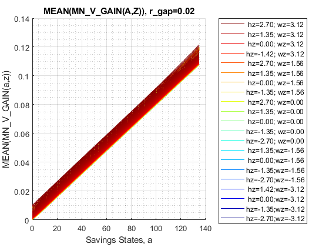

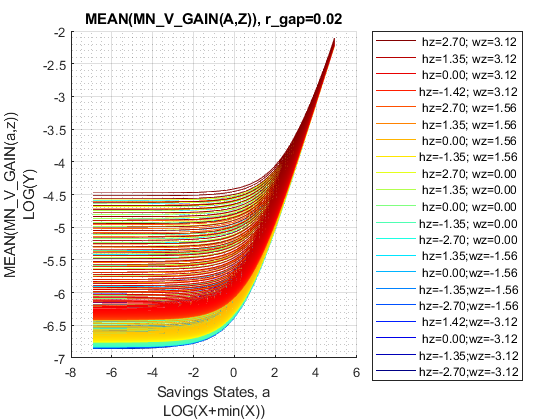

Graph Mean Consumption:

```
st_title = ['MEAN(MN\_C\_GAIN(A,Z)), r\_gap=' num2str(fl_r_gap)  ''];
mp_support_graph('cl_st_graph_title') = {st_title};
mp_support_graph('cl_st_ytitle') = {'MEAN(MN\_C\_GAIN(a,z))'};
ff_graph_grid((tb_az_c{1:end, 3:end})', ar_st_eta_HS_grid, agrid, mp_support_graph);
```

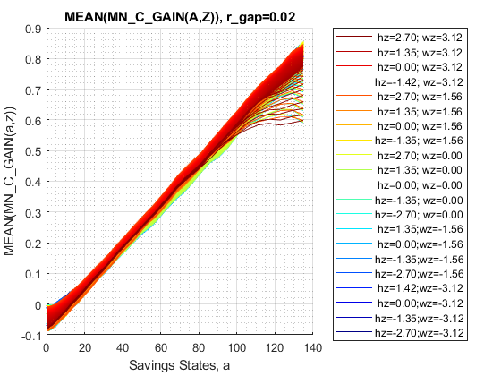

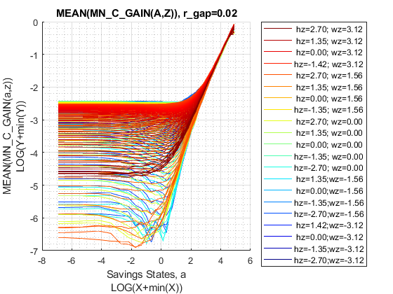

## 1.6 Analyze Kids and Marriage and Age

Aggregating over education, savings, and shocks, what are the differential effects of Marriage and Age.

```
% Generate some Data
mp_support_graph = containers.Map('KeyType', 'char', 'ValueType', 'any');
ar_row_grid = [...
    "k0M0", "K1M0", "K2M0", "K3M0", "K4M0", ...
    "k0M1", "K1M1", "K2M1", "K3M1", "K4M1"];
mp_support_graph('cl_st_xtitle') = {'Age'};
mp_support_graph('st_legend_loc') = 'best';
mp_support_graph('bl_graph_logy') = true; % do not log
mp_support_graph('st_rounding') = '6.2f'; % format shock legend
mp_support_graph('cl_scatter_shapes') = {...
    'o', 'd' ,'s', 'x', '*', ...
    'o', 'd', 's', 'x', '*'};
mp_support_graph('cl_colors') = {...
    'red', 'red', 'red', 'red', 'red'...
    'blue', 'blue', 'blue', 'blue', 'blue'};
```

MEAN(VAL(KM,J)), MEAN(AP(KM,J)), MEAN(C(KM,J))

Tabulate value and policies:

```
% Set
% NaN(n_jgrid,n_agrid,n_etagrid,n_educgrid,n_marriedgrid,n_kidsgrid);
ar_permute = [2,3,4,1,6,5];
% Value Function
st_title = ['MEAN(MN_V_Gain(KM,J)), r_gap=' num2str(fl_r_gap) ];
tb_az_v = ff_summ_nd_array(st_title, mn_V_gain_r, true, ["mean"], 3, 1, cl_mp_datasetdesc, ar_permute);

xxx  MEAN(MN_V_Gain(KM,J)), r_gap=0.02  xxxxxxxxxxxxxxxxxxxxxxxxxxx
    group    kids    marry    mean_age_18    mean_age_19    mean_age_20    mean_age_21    mean_age_22    mean_age_23    mean_age_24    mean_age_25    mean_age_26    mean_age_27    mean_age_28    mean_age_29    mean_age_30    mean_age_31    mean_age_32    mean_age_33    mean_age_34    mean_age_35    …
    _____    ____    _____    ___________    ___________    ___________    ___________    ___________    ___________    ___________    ___________    ___________    ___________    ___________    ___________    ___________    ___________    ___________    ___________    ___________    ___________    …

      1       1        0        0.015087       0.015546       0.016026        0.01653       0.017025       0.017508       0.017978       0.018434       0.018873       0.019295       0.019699       0.020086       0.020454       0.020804       0.021136       0.021452      0.021751       0.022035      …
      2       2        0        0.011707       0.012061       0.012444       0.012858       0.013278       0.013703        0.01413       0.014557       0.014983       0.015407       0.015825       0.016238       0.016643       0.017039       0.017426       0.017803      0.018169       0.018525      …
      3       3        0        0.010499       0.010777       0.011081       0.011412       0.011749       0.012091       0.012436       0.012784       0.013132        0.01348       0.013827       0.014172       0.014513       0.014851       0.015184       0.015512      0.015835       0.016152      …
      4       4        0       0.0094894      0.0097107      0.0099547       0.010224         0.0105       0.010781       0.011067       0.011357       0.011649       0.011943       0.012238       0.012533       0.012828       0.013122       0.013414       0.013704      0.013992       0.014277      …
      5       5        0         0.00886      0.0090319      0.0092234      0.0094371      0.0096558      0.0098787       0.010105       0.010335       0.010567       0.010801       0.011036       0.011272       0.011509       0.011746       0.011983        0.01222      0.012456       0.012691      …
      6       1        1        0.010229       0.010593       0.010984       0.011405       0.011831       0.012259       0.012687       0.013111        0.01353       0.013941       0.014341       0.014729       0.015103       0.015462       0.015804        0.01613      0.016438       0.016728      …
      7       2        1        0.008528      0.0087978      0.0090932      0.0094182      0.0097531       0.010096       0.010446         0.0108       0.011157       0.011516       0.011874        0.01223       0.012581       0.012928       0.013267       0.013598       0.01392       0.014232      …
      8       3        1       0.0079012      0.0081252      0.0083716      0.0086439      0.0089244      0.0092117      0.0095044      0.0098013       0.010101       0.010402       0.010704       0.011004       0.011302       0.011596       0.011886       0.012171       0.01245       0.012723      …
      9       4        1       0.0073246      0.0075062      0.0077075      0.0079319      0.0081637      0.0084017       0.008645      0.0088926      0.0091435      0.0093967      0.0096513      0.0099063       0.010161       0.010414       0.010665       0.010913      0.011158       0.011399      …
     10       5        1         0.00696      0.0071075      0.0072717      0.0074553       0.007644      0.0078372       0.008034      0.0082336      0.0084355      0.0086389      0.0088431      0.0090474      0.0092514      0.0094545      0.0096564      0.0098567      0.010055       0.010251      …

% Consumption Function
st_title = ['MEAN(MN_C_Gain(KM,J)), r_gap=' num2str(fl_r_gap) ];
tb_az_c = ff_summ_nd_array(st_title, mn_C_gain_r, true, ["mean"], 3, 1, cl_mp_datasetdesc, ar_permute);

```

[output cut: 14 more lines]

Graph Mean Values:

```
st_title = ['MEAN(MN\_V\_GAIN(KM,J)), r\_gap=' num2str(fl_r_gap)  ''];
mp_support_graph('cl_st_graph_title') = {st_title};
mp_support_graph('cl_st_ytitle') = {'MEAN(MN\_V\_GAIN(KM,J))'};
ff_graph_grid((tb_az_v{1:end, 4:end}), ar_row_grid, age_grid, mp_support_graph);
```

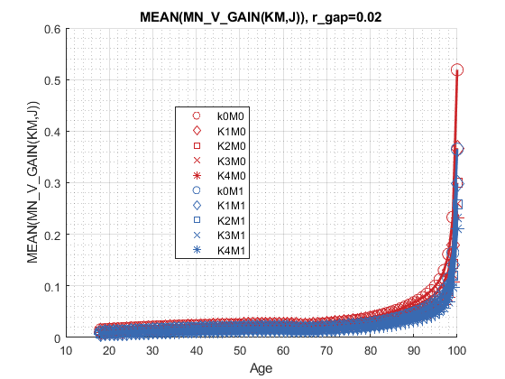

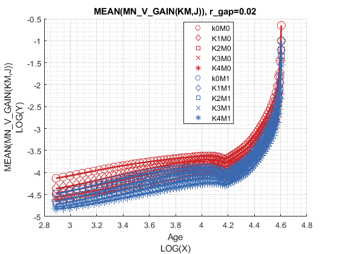

Graph Mean Consumption:

```
st_title = ['MEAN(MN\_C\_GAIN(KM,J)), r\_gap=' num2str(fl_r_gap)  ''];
mp_support_graph('cl_st_graph_title') = {st_title};
mp_support_graph('cl_st_ytitle') = {'MEAN(MN\_C\_GAIN(KM,J))'};
ff_graph_grid((tb_az_c{1:end, 4:end}), ar_row_grid, age_grid, mp_support_graph);
```

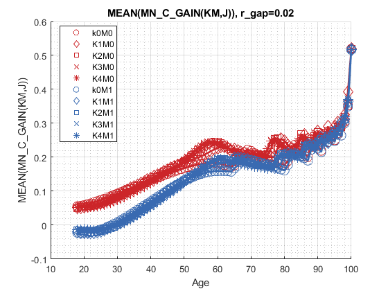

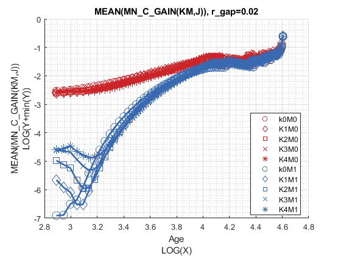

## 1.7 Analyze Education and Marriage

```
% Generate some Data
mp_support_graph = containers.Map('KeyType', 'char', 'ValueType', 'any');
ar_row_grid = ["E0M0", "E1M0", "E0M1", "E1M1"];
mp_support_graph('cl_st_xtitle') = {'Age'};
mp_support_graph('st_legend_loc') = 'best';
mp_support_graph('bl_graph_logy') = true; % do not log
mp_support_graph('st_rounding') = '6.2f'; % format shock legend
mp_support_graph('cl_scatter_shapes') = {'*', 'p', '*','p' };
mp_support_graph('cl_colors') = {'red', 'red', 'blue', 'blue'};
```

MEAN(VAL(EM,J)), MEAN(AP(EM,J)), MEAN(C(EM,J))

Tabulate value and policies:

```
% Set
% NaN(n_jgrid,n_agrid,n_etagrid,n_educgrid,n_marriedgrid,n_kidsgrid);
ar_permute = [2,3,6,1,4,5];
% Value Function
st_title = ['MEAN(MN_V_Gain(EM,J)), r_gap=' num2str(fl_r_gap) ];
tb_az_v = ff_summ_nd_array(st_title, mn_V_gain_r, true, ["mean"], 3, 1, cl_mp_datasetdesc, ar_permute);

xxx  MEAN(MN_V_Gain(EM,J)), r_gap=0.02  xxxxxxxxxxxxxxxxxxxxxxxxxxx
    group    edu    marry    mean_age_18    mean_age_19    mean_age_20    mean_age_21    mean_age_22    mean_age_23    mean_age_24    mean_age_25    mean_age_26    mean_age_27    mean_age_28    mean_age_29    mean_age_30    mean_age_31    mean_age_32    mean_age_33    mean_age_34    mean_age_35    m…
    _____    ___    _____    ___________    ___________    ___________    ___________    ___________    ___________    ___________    ___________    ___________    ___________    ___________    ___________    ___________    ___________    ___________    ___________    ___________    ___________    _…

      1       0       0        0.011474       0.011736       0.012012       0.012305       0.012599       0.012892       0.013186      0.013479       0.013772       0.014063       0.014352       0.014639       0.014923       0.015204       0.015481       0.015755       0.016026       0.016292       …
      2       1       0        0.010783       0.011115       0.011479       0.011879       0.012285       0.012692         0.0131      0.013507       0.013909       0.014307       0.014698       0.015081       0.015456       0.015821       0.016176       0.016521       0.016856        0.01718       …
      3       0       1       0.0084099      0.0086195      0.0088444      0.0090861      0.0093328      0.0095836      0.0098377      0.010094       0.010353       0.010612       0.010871       0.011129       0.011385       0.011638       0.011888       0.012133       0.012374       0.012608       …
      4       1       1       0.0079671      0.0082324      0.0085268      0.0088556      0.0091936      0.0095387      0.0098885      0.010241       0.010594       0.010945       0.011294       0.011637       0.011974       0.012303       0.012624       0.012934       0.013235       0.013525       …

% Consumption
st_title = ['MEAN(MN_C_Gain(EM,J)), r_gap=' num2str(fl_r_gap) ];
tb_az_c = ff_summ_nd_array(st_title, mn_C_gain_r, true, ["mean"], 3, 1, cl_mp_datasetdesc, ar_permute);

xxx  MEAN(MN_C_Gain(EM,J)), r_gap=0.02  xxxxxxxxxxxxxxxxxxxxxxxxxxx
    group    edu    marry    mean_age_18    mean_age_19    mean_age_20    mean_age_21    mean_age_22    mean_age_23    mean_age_24    mean_age_25    mean_age_26    mean_age_27    mean_age_28    mean_age_29    mean_age_30    mean_age_31    mean_age_32    mean_age_33    mean_age_34    mean_age_35    m…
    _____    ___    _____    ___________    ___________    ___________    ___________    ___________    ___________    ___________    ___________    ___________    ___________    ___________    ___________    ___________    ___________    ___________    ___________    ___________    ___________    _…

      1       0       0         0.06916       0.070507        0.072258       0.07446       0.076888        0.07952        0.08235       0.085374       0.088556       0.09186        0.095357       0.098967        0.10267       0.10654         0.11044        0.11449       0.11863         0.12276      …
      2       1       0        0.035018       0.036932        0.038237       0.03745       0.037691       0.038982        0.04119       0.044138       0.047676       0.05168        0.056051       0.060711       0.065613      0.070681        0.075906       0.081252      0.086686        0.092198      …
      3       0       1      -0.0014877      -0.001014     -0.00023405    0.00057466      0.0018134      0.0035145       0.005632      0.0081906       0.011124      0.014436        0.018113         0.0221       0.026382      0.030941        0.035761       0.040792      0.046032        0.051454      …
      4       1       1       -0.032339      -0.033466       -0.034261     -0.037595      -0.039904      -0.041093      -0.041076      -0.039973      -0.037899      -0.03494       -0.031243      -0.026935      -0.022065      -0.01671       -0.010961      -0.004835      0.001578       0.0082787      …
```

Graph Mean Values:

```
st_title = ['MEAN(MN\_V\_GAIN(EM,J)), r\_gap=' num2str(fl_r_gap)  ''];
mp_support_graph('cl_st_graph_title') = {st_title};
mp_support_graph('cl_st_ytitle') = {'MEAN(MN\_V\_GAIN(EM,J))'};
ff_graph_grid((tb_az_v{1:end, 4:end}), ar_row_grid, age_grid, mp_support_graph);
```

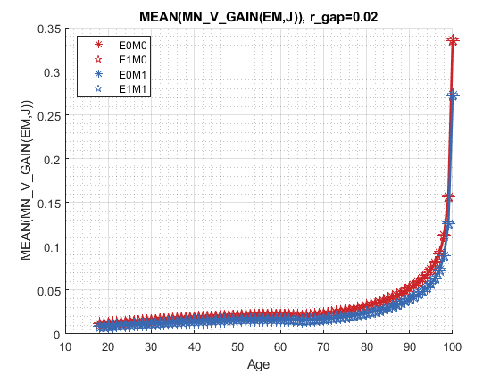

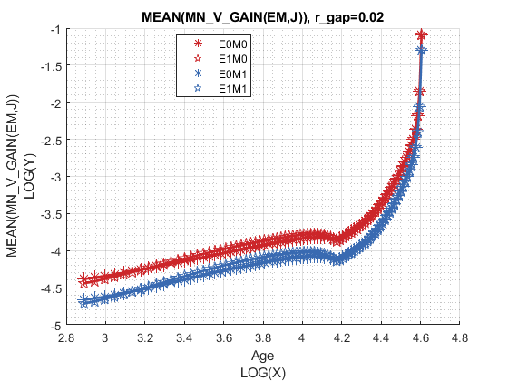

Graph Mean Consumption:

```
st_title = ['MEAN(MN\_C\_GAIN(EM,J)), r\_gap=' num2str(fl_r_gap)  ''];
mp_support_graph('cl_st_graph_title') = {st_title};
mp_support_graph('cl_st_ytitle') = {'MEAN(MN\_C\_GAIN(EM,J))'};
ff_graph_grid((tb_az_c{1:end, 4:end}), ar_row_grid, age_grid, mp_support_graph);
```

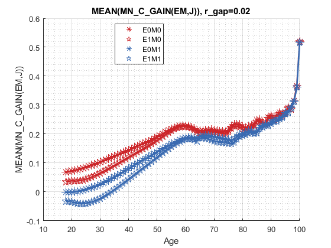

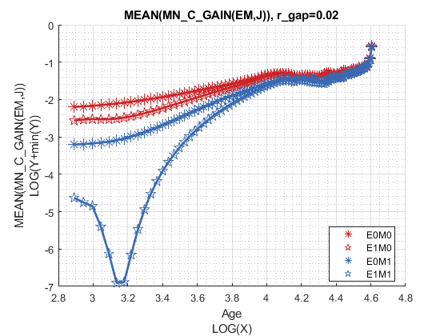